# Part I - Ford Gobike Data Exploration

# Daily Trip Duration by User-Type

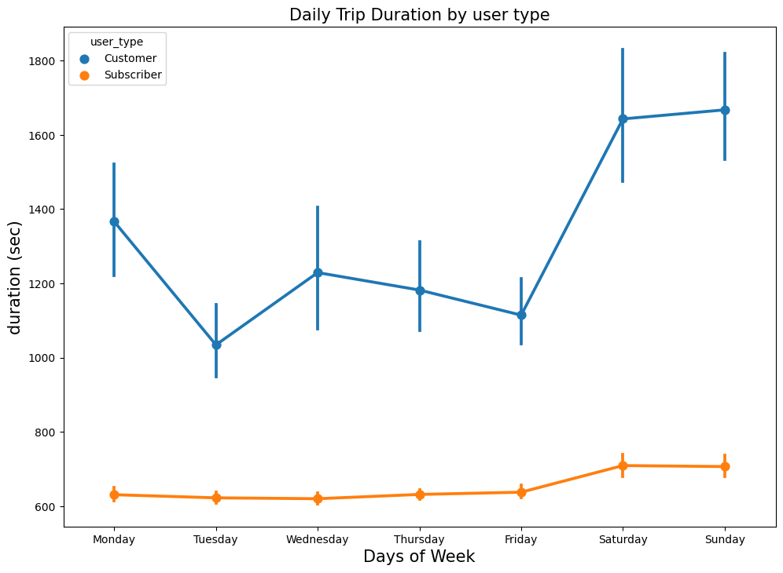

```python
plt.figure(figsize=[11.69, 8.27])
sb.pointplot(data = ford_gobike_clean, x = 'start_day_id', y = 'duration_sec', hue = 'user_type')

x_y_t('Days of Week','duration (sec)','Daily Trip Duration by user type')
plt.xticks([0,1,2,3,4,5,6],['Monday', 'Tuesday','Wednesday','Thursday','Friday','Saturday', 'Sunday']);
plt.show()
```

The plot above clearly shows that customers spent a longer time riding the bike than the subscribers regardless of the day of the weeks, with both parties spending significantly more time on the weekends than weekdays. It can also be observed than customers spend more time on Monday than they did for any other weekday.

### Talk about some of the relationships you observed in this part of the investigation. Were there features that strengthened each other in terms of looking at your feature(s) of interest?

[output not shown]

### Were there any interesting or surprising interactions between features?

[output not shown]